# **ExtraaLearn Project**

### **Tuning the XGBoost Model (GridsearchCV)**

To further optimize the XGBoost Classifier, we will perform hyperparameter tuning using GridSearchCV. This will involve searching over a predefined grid of hyperparameter values to find the combination that yields the best performance on the training data through cross-validation.

We will tune the following hyperparameters:

- `n_estimators`: The number of boosting rounds or trees.
- `learning_rate`: Step size shrinkage used in update to prevent overfitting.
- `max_depth`: Maximum depth of a tree.
- `min_child_weight`: Minimum sum of instance weight (hessian) needed in a child.
- `gamma`: Minimum loss reduction required to make a further partition on a leaf node of the tree.
- `subsample`: Fraction of samples used per tree.
- `colsample_bytree`: Fraction of features used per tree.

```python
# Define the hyperparameter grid for XGBoost tuning
param_grid_xgb = {
    'n_estimators': [100, 200, 300], # Number of boosting rounds
    'learning_rate': [0.01, 0.1, 0.2], # Step size shrinkage
    'max_depth': [3, 5, 7], # Maximum tree depth
    'min_child_weight': [1, 3, 5], # Minimum child weight
    'gamma': [0, 0.1, 0.2], # Minimum loss reduction required
    'subsample': [0.8, 1.0], # Fraction of samples for trees
    'colsample_bytree': [0.8, 1.0] # Fraction of features for trees
}

# Print the defined hyperparameter grid
print(param_grid_xgb)
```

```
{'n_estimators': [100, 200, 300], 'learning_rate': [0.01, 0.1, 0.2], 'max_depth': [3, 5, 7], 'min_child_weight': [1, 3, 5], 'gamma': [0, 0.1, 0.2], 'subsample': [0.8, 1.0], 'colsample_bytree': [0.8, 1.0]}
```

```python
# Initialize XGBoost Classifier model
xgb_model = XGBClassifier(random_state=42)

# Initialize GridSearchCV
grid_search_xgb = GridSearchCV(estimator=xgb_model, param_grid=param_grid_xgb,
                             cv=5, scoring='roc_auc', n_jobs=-1, verbose=2) # Using roc_auc as the scoring metric, with 5-fold cross-validation

# Fit GridSearchCV to the training data
grid_search_xgb.fit(X_train, y_train)

# Print the best hyperparameters found by GridSearchCV
print("Best hyperparameters found by GridSearchCV:", grid_search_xgb.best_params_)
```

```
Fitting 5 folds for each of 972 candidates, totalling 4860 fits
Best hyperparameters found by GridSearchCV: {'colsample_bytree': 1.0, 'gamma': 0, 'learning_rate': 0.01, 'max_depth': 5, 'min_child_weight': 1, 'n_estimators': 300, 'subsample': 1.0}
```

```python
# Initialize a new XGBoost model with the best hyperparameters found by GridSearchCV
tuned_xgb_model = XGBClassifier(**grid_search_xgb.best_params_, random_state=42)

# Train the tuned model and measure training time
start_time = time.time()
tuned_xgb_model.fit(X_train, y_train)
training_time_tuned_xgb = time.time() - start_time

# Make predictions on the training and testing sets and measure prediction time
start_time = time.time()
y_train_pred_tuned_xgb = tuned_xgb_model.predict(X_train)
train_prediction_time_tuned_xgb = time.time() - start_time

start_time = time.time()
y_test_pred_tuned_xgb = tuned_xgb_model.predict(X_test)
test_prediction_time_tuned_xgb = time.time() - start_time

# Get predicted probabilities for the testing set
y_test_proba_tuned_xgb = tuned_xgb_model.predict_proba(X_test)[:, 1]

# Evaluate the tuned model
test_report_tuned_xgb = classification_report(y_test, y_test_pred_tuned_xgb, output_dict=True)
test_roc_auc_tuned_xgb = roc_auc_score(y_test, y_test_proba_tuned_xgb)


# Store results in the dictionary
model_results['Tuned XGBoost'] = {
    'Training Report': classification_report(y_train, y_train_pred_tuned_xgb, output_dict=True),
    'Training ROC AUC': roc_auc_score(y_train, tuned_xgb_model.predict_proba(X_train)[:, 1]),
    'Training Confusion Matrix': confusion_matrix(y_train, y_train_pred_tuned_xgb).tolist(),
    'Training Time (s)': training_time_tuned_xgb,
    'Training Prediction Time (s)': train_prediction_time_tuned_xgb,
    'Testing Report': test_report_tuned_xgb,
    'Testing ROC AUC': test_roc_auc_tuned_xgb,
    'Testing Confusion Matrix': confusion_matrix(y_test, y_test_pred_tuned_xgb).tolist(),
    'Testing Prediction Time (s)': test_prediction_time_tuned_xgb,
    'Testing Probabilities': y_test_proba_tuned_xgb.tolist() # Store testing probabilities
}
```

```
Model Comparison Table (Sorted by Test ROC AUC):
```

|  | Accuracy (Train) | Precision (Train - Converted) | Recall (Train - Converted) | F1-score (Train - Converted) | ROC AUC (Train) | Accuracy (Test) | Precision (Test - Converted) | Recall (Test - Converted) | F1-score (Test - Converted) | ROC AUC (Test) | Training Time (s) | Prediction Time (s) |
| --- | --- | --- | --- | --- | --- | --- | --- | --- | --- | --- | --- | --- |
| Tuned XGBoost | 0.882001 | 0.807331 | 0.789522 | 0.798327 | 0.950364 | 0.865217 | 0.800738 | 0.756098 | 0.777778 | 0.931214 | 0.450918 | 0.008360 |
| Tuned Random Forest | 0.911365 | 0.877976 | 0.813419 | 0.844466 | 0.973713 | 0.857609 | 0.800000 | 0.724739 | 0.760512 | 0.928205 | 1.754174 | 0.051781 |
| Tuned AdaBoost | 0.863785 | 0.784675 | 0.743566 | 0.763568 | 0.927920 | 0.867391 | 0.795699 | 0.773519 | 0.784452 | 0.926986 | 2.980228 | 0.061703 |
| Pruned Decision Tree | 0.873029 | 0.802927 | 0.756434 | 0.778987 | 0.925634 | 0.860870 | 0.806950 | 0.728223 | 0.765568 | 0.919101 | 0.028307 | 0.003221 |
| Random Forest | 0.999728 | 0.999082 | 1.000000 | 0.999541 | 1.000000 | 0.858696 | 0.807843 | 0.717770 | 0.760148 | 0.915903 | 0.740377 | 0.023888 |
| XGBoost | 0.994834 | 0.990817 | 0.991728 | 0.991272 | 0.999878 | 0.843478 | 0.778210 | 0.696864 | 0.735294 | 0.914995 | 0.289589 | 0.007310 |
| AdaBoost | 0.820827 | 0.730893 | 0.624081 | 0.673277 | 0.891255 | 0.831522 | 0.764000 | 0.665505 | 0.711359 | 0.896791 | 0.321103 | 0.015031 |
| Logistic Regression | 0.834693 | 0.769663 | 0.629596 | 0.692619 | 0.867507 | 0.844565 | 0.788000 | 0.686411 | 0.733706 | 0.883454 | 0.063303 | 0.013574 |
| Decision Tree | 0.999728 | 1.000000 | 0.999081 | 0.999540 | 1.000000 | 0.810870 | 0.687708 | 0.721254 | 0.704082 | 0.786378 | 0.035452 | 0.002146 |

```
--- Confusion Matrices for Top 5 Models (Based on Test ROC AUC) ---
```

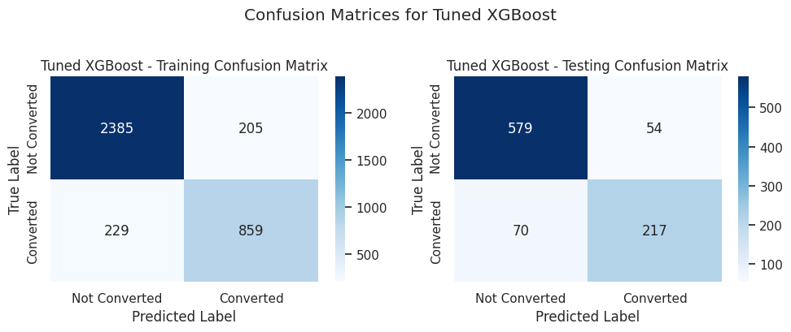

```
Feature Importances (Tuned XGBoost):
```

|  | 0 |
| --- | --- |
| first_interaction_Website | 0.351882 |
| profile_completed_Medium | 0.145308 |
| time_spent_on_website | 0.133172 |
| last_activity_Phone Activity | 0.062363 |
| profile_completed_Low | 0.047955 |
| current_occupation_Unemployed | 0.045572 |
| age | 0.035254 |
| last_activity_Website Activity | 0.030382 |
| current_occupation_Student | 0.028745 |
| referral_Yes | 0.025228 |
| educational_channels_Yes | 0.024064 |
| print_media_type1_Yes | 0.018299 |
| website_engagement | 0.014649 |
| website_visits | 0.011719 |
| interaction_score | 0.010814 |
| page_views_per_visit | 0.010123 |
| media_interaction | 0.004473 |
| digital_media_Yes | 0.000000 |
| print_media_type2_Yes | 0.000000 |

**dtype:** float32

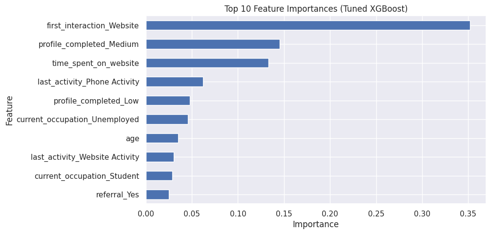

```python
# Display the model comparison table after Tuned XGBoost and capture the sorted DataFrame
results_df_sorted = display_model_comparison_table(model_results)

# Plot confusion matrices for the top models (adjust n as needed to include the new model)
plot_top_n_confusion_matrices(model_results, results_df_sorted, min(len(model_results), 5)) # Display up to top 5 or fewer

# Display feature importance for the Tuned XGBoost model
display_feature_importance(tuned_xgb_model, X_train.columns, 'Tuned XGBoost')
```